# Practical machine learning - assignment report

### Loading neccesary libraries

```r
library(doParallel)
library(knitr)
library(caret)
library(randomForest)
library(ggplot2)
library(reshape2)
```

### Setting up working directory and register parallel

```r
setwd("/mnt/data1/oskar/pml/")
registerDoParallel(detectCores())
# knitr sometimes refuses to co-work with Parallel package
# but works with instruction knit2html()
```

### Reading data

```r
ultima <- read.csv("/mnt/data1/oskar/pml/pml-testing.csv",
                   header = T,
                   na.strings = "NA", row.names = 1)
dataset <- read.csv("/mnt/data1/oskar/pml/pml-training.csv",
                   header = T,
                   na.strings = c("NA","#DIV/0!"),
                   row.names = 1)
```

### Cleaning data

```
## stat_bin: binwidth defaulted to range/30. Use 'binwidth = x' to adjust this.
```

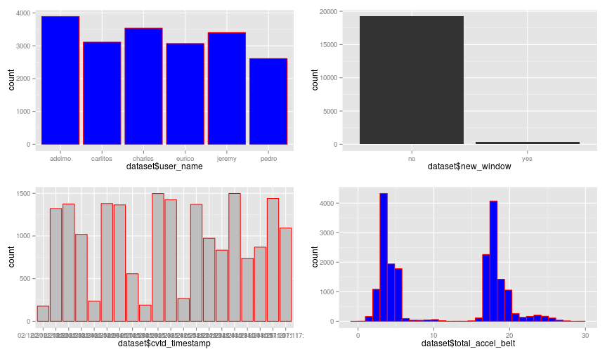

```r
# data is dirty, cleaning it here and fixing col types
dataset$kurtosis_roll_belt = as.numeric(dataset$kurtosis_roll_belt)
dataset$kurtosis_picth_dumbbell = as.numeric(dataset$kurtosis_picth_dumbbell)
dataset$skewness_roll_dumbbell = as.numeric(dataset$skewness_roll_dumbbell)
dataset$skewness_pitch_dumbbell = as.numeric(dataset$skewness_pitch_dumbbell)
dataset$max_yaw_dumbbell = as.numeric(dataset$max_yaw_dumbbell)
dataset$min_yaw_dumbbell = as.numeric(dataset$min_yaw_dumbbell)
# remove unwanted columns, too obvious or useless
p1 <- qplot(dataset$user_name, geom="histogram",
            fill=I("blue"), col=I("red"))
p2 <- qplot(dataset$cvtd_timestamp, geom="histogram",
            fill=I("grey"), col=I("red"))
p3 <- qplot(dataset$new_window, geom="histogram")
p4 <- qplot(dataset$total_accel_belt, geom="histogram",
            fill=I("blue"), col=I("red"))
multiplot(p1, p2, p3, p4, cols=2)
```

### Removing unwanted columns, which are too obvious and may cause overfitting

```r
dataset <- dataset[,-which(names(dataset) %in% c(
   "user_name","cvtd_timestamp", "new_window", "num_window"))]
```

### Partitioning data for train and test cases, p=0.75 by rule of thumb

```r
testIndex = createDataPartition(dataset$classe, p = 3/4)[[1]]
testing = dataset[-testIndex,]
training = dataset[testIndex,]
```

### Data cleaning part 2

```r
# remove columns which have only NA in all rows
testing <- testing[,colSums(is.na(testing))<nrow(testing)]
training <- training[,colSums(is.na(training))<nrow(training)]
# remove zero variance columns
zero_v_train <-
   names(training[, sapply(
      training, function(v) var(v, na.rm=TRUE)==0)])
training <- training[,-which(names(training) %in% zero_v_train)]
testing <- testing[,-which(names(testing) %in% zero_v_train)]
```

### Principal component analysis

```r
cls_indx = which(names(training) %in% c("classe"))
set.seed(31337)
preProc <- preProcess(training[,-cls_indx], method="pca", thresh=0.85)
preProc
```

```
##
## Call:
## preProcess.default(x = training[, -cls_indx], method = "pca", thresh
##  = 0.85)
##
## Created from 161 samples and 145 variables
## Pre-processing: principal component signal extraction, scaled, centered
##
## PCA needed 27 components to capture 85 percent of the variance
```

```r
# delete columns with at least 1 or more NA value
training <- training[, colSums(is.na(training)) == 0]
testing <- testing[, colSums(is.na(testing)) == 0]
# check again PCA with threshold 0.85
cls_indx = which(names(training) %in% c("classe"))
set.seed(31337)
preProc <- preProcess(training[,-cls_indx], method="pca", thresh=0.85)
preProc
```

```
##
## Call:
## preProcess.default(x = training[, -cls_indx], method = "pca", thresh
##  = 0.85)
##
## Created from 14718 samples and 54 variables
## Pre-processing: principal component signal extraction, scaled, centered
##
## PCA needed 17 components to capture 85 percent of the variance
```

### Check different models below

```r
variable.group = colnames(training)
melted <- melt(preProc$rotation[,1:9]) # cbind(variable.group,
barplot <- ggplot(data=melted) +
  geom_bar(aes(x=Var1, y=value, fill=variable.group), stat="identity") +
  facet_wrap(~Var2)
barplot
```

[output not shown]

### Part A: Check models on PCA-selected features only

#### Naive Bayes

```r
set.seed(31337)
modelFit <- train(classe ~ ., method="nb", data=training,
                  trControl = trainControl(
                     preProcOptions = list(thresh = 0.85)
                  ),
                  preProcess = "pca")
confusionMatrix(testing$classe, predict(modelFit,testing))
```

```
## Confusion Matrix and Statistics
##
##           Reference
## Prediction   A   B   C   D   E
##          A 860  82 256 163  34
##          B  76 579 140  67  87
##          C 182  83 523  34  33
##          D  62  67 132 480  63
##          E  61 144  74  73 549
##
## Overall Statistics
##
##                Accuracy : 0.6099
##                  95% CI : (0.5961, 0.6236)
##     No Information Rate : 0.2531
##     P-Value [Acc > NIR] : < 2.2e-16
##
##                   Kappa : 0.5089
##  Mcnemar's Test P-Value : < 2.2e-16
##
## Statistics by Class:
##
##                      Class: A Class: B Class: C Class: D Class: E
## Sensitivity            0.6930   0.6063   0.4649  0.58752   0.7167
## Specificity            0.8539   0.9063   0.9121  0.92072   0.9149
## Pos Pred Value         0.6165   0.6101   0.6117  0.59701   0.6093
## Neg Pred Value         0.8914   0.9049   0.8513  0.91780   0.9458
## Prevalence             0.2531   0.1947   0.2294  0.16660   0.1562
## Detection Rate         0.1754   0.1181   0.1066  0.09788   0.1119
## Detection Prevalence   0.2845   0.1935   0.1743  0.16395   0.1837
## Balanced Accuracy      0.7735   0.7563   0.6885  0.75412   0.8158
```

#### Generalized Linear Model

##### Because 'classe' is a field suggesting a multi-label classification problem, we shouldn't really use glm which works best on binary classes {0,1}

```r
# set.seed(31337)
# modelFit <- train(classe ~ ., method="glm", data=training,
#                   trControl = trainControl(
#                      preProcOptions = list(thresh = 0.85)
#                   ),
#                   preProcess = "pca")
# confusionMatrix(testing$classe, predict(modelFit,testing))
```

#### Linear Discriminant Analysis

```r
set.seed(31337)
modelFit <- train(classe ~ ., method="lda",
                  preProcess="pca",
                  trControl = trainControl(
                     preProcOptions = list(thresh = 0.85)
                  ),
                  data=training)
# took around 2 minutes
confusionMatrix(testing$classe, predict(modelFit,testing))
```

```
## Confusion Matrix and Statistics
##
##           Reference
## Prediction   A   B   C   D   E
##          A 946 101 127 181  40
##          B 191 417 119 130  92
##          C 352 100 299  53  51
##          D  94 171  82 375  82
##          E 147 147  91  98 418
##
## Overall Statistics
##
##                Accuracy : 0.5006
##                  95% CI : (0.4865, 0.5147)
##     No Information Rate : 0.3528
##     P-Value [Acc > NIR] : < 2.2e-16
##
##                   Kappa : 0.3627
##  Mcnemar's Test P-Value : < 2.2e-16
##
## Statistics by Class:
##
##                      Class: A Class: B Class: C Class: D Class: E
## Sensitivity            0.5468  0.44551  0.41643  0.44803  0.61201
## Specificity            0.8585  0.86593  0.86718  0.89452  0.88557
## Pos Pred Value         0.6781  0.43941  0.34971  0.46642  0.46393
## Neg Pred Value         0.7766  0.86877  0.89652  0.88732  0.93380
## Prevalence             0.3528  0.19086  0.14641  0.17068  0.13927
## Detection Rate         0.1929  0.08503  0.06097  0.07647  0.08524
## Detection Prevalence   0.2845  0.19352  0.17435  0.16395  0.18373
## Balanced Accuracy      0.7027  0.65572  0.64181  0.67127  0.74879
```

#### k-Nearest Neighbors

```r
set.seed(31337)
modelFit <- train(classe ~ ., method="knn",
                  trControl = trainControl(
                    method="cv", number = 5,
                    preProcOptions = list(thresh = 0.85)
                  ),
                  preProcess="pca",
                  data=training)
# took around 7-8 minutes
confusionMatrix(testing$classe, predict(modelFit,testing))
```

```
## Confusion Matrix and Statistics
##
##           Reference
## Prediction    A    B    C    D    E
##          A 1354   12   15   11    3
##          B   22  900   24    3    0
##          C   10   16  807   17    5
##          D    8    4   40  748    4
##          E    5    8    9    6  873
##
## Overall Statistics
##
##                Accuracy : 0.9547
##                  95% CI : (0.9485, 0.9604)
##     No Information Rate : 0.2853
##     P-Value [Acc > NIR] : < 2.2e-16
##
##                   Kappa : 0.9427
##  Mcnemar's Test P-Value : 0.004504
##
## Statistics by Class:
##
##                      Class: A Class: B Class: C Class: D Class: E
## Sensitivity            0.9678   0.9574   0.9017   0.9529   0.9864
## Specificity            0.9883   0.9876   0.9880   0.9864   0.9930
## Pos Pred Value         0.9706   0.9484   0.9439   0.9303   0.9689
## Neg Pred Value         0.9872   0.9899   0.9783   0.9910   0.9970
## Prevalence             0.2853   0.1917   0.1825   0.1601   0.1805
## Detection Rate         0.2761   0.1835   0.1646   0.1525   0.1780
## Detection Prevalence   0.2845   0.1935   0.1743   0.1639   0.1837
## Balanced Accuracy      0.9781   0.9725   0.9449   0.9696   0.9897
```

##### From now on, all models with high accuracy will get k-fold cross validated

##### Hence the trainControl with method=“cv” instructions in algorithms producing > 0.75 accuracy

##### High accuracy, printing possible solutions

```r
answers1 <- predict(modelFit, ultima)
# answers produced from k-nn model with PCA
```

#### Random Forests

```r
set.seed(31337)
modelFit <- train(classe ~ ., method="rf",
                  trControl = trainControl(
                    method = "oob",
                    preProcOptions = list(thresh = 0.85)
                  ),
                  preProcess="pca",
                  data=training)
# took around 7-8 minutes
confusionMatrix(testing$classe, predict(modelFit,testing))
```

```
## Confusion Matrix and Statistics
##
##           Reference
## Prediction    A    B    C    D    E
##          A 1376    4    5    8    2
##          B   14  926    8    0    1
##          C    4   15  832    2    2
##          D    7    7   35  752    3
##          E    0   11    5    4  881
##
## Overall Statistics
##
##                Accuracy : 0.9721
##                  95% CI : (0.9671, 0.9765)
##     No Information Rate : 0.2857
##     P-Value [Acc > NIR] : < 2.2e-16
##
##                   Kappa : 0.9647
##  Mcnemar's Test P-Value : 2.002e-08
##
## Statistics by Class:
##
##                      Class: A Class: B Class: C Class: D Class: E
## Sensitivity            0.9822   0.9616   0.9401   0.9817   0.9910
## Specificity            0.9946   0.9942   0.9943   0.9874   0.9950
## Pos Pred Value         0.9864   0.9758   0.9731   0.9353   0.9778
## Neg Pred Value         0.9929   0.9906   0.9869   0.9966   0.9980
## Prevalence             0.2857   0.1964   0.1805   0.1562   0.1813
## Detection Rate         0.2806   0.1888   0.1697   0.1533   0.1796
## Detection Prevalence   0.2845   0.1935   0.1743   0.1639   0.1837
## Balanced Accuracy      0.9884   0.9779   0.9672   0.9846   0.9930
```

```r
summary(modelFit$err.rate)
```

```
## Length  Class   Mode
##      0   NULL   NULL
```

##### Random forest is an exception described in literature, and for validation it uses 'oob' (“out of bounds”) method

##### High accuracy, printing possible solutions

```r
answers2 <- predict(modelFit, ultima)
# answers produced from Random Forest with PCA
```

#### Multinomial

```r
set.seed(31337)
modelFit <- train(classe ~ ., method="multinom",
                  trControl = trainControl(
                     preProcOptions = list(thresh = 0.85)
                  ),
                  preProcess="pca", data=training)
# and that took around 5-7 minutes..
confusionMatrix(testing$classe, predict(modelFit,testing))
```

```
## Confusion Matrix and Statistics
##
##           Reference
## Prediction   A   B   C   D   E
##          A 964  69 125 183  54
##          B 188 387 117 151 106
##          C 344  82 325  54  50
##          D 102 140  77 392  93
##          E 137 136 118 103 407
##
## Overall Statistics
##
##                Accuracy : 0.5047
##                  95% CI : (0.4906, 0.5188)
##     No Information Rate : 0.3538
##     P-Value [Acc > NIR] : < 2.2e-16
##
##                   Kappa : 0.3682
##  Mcnemar's Test P-Value : < 2.2e-16
##
## Statistics by Class:
##
##                      Class: A Class: B Class: C Class: D Class: E
## Sensitivity            0.5556  0.47543  0.42651  0.44394  0.57324
## Specificity            0.8640  0.86259  0.87204  0.89754  0.88221
## Pos Pred Value         0.6910  0.40780  0.38012  0.48756  0.45172
## Neg Pred Value         0.7803  0.89204  0.89207  0.88024  0.92431
## Prevalence             0.3538  0.16599  0.15538  0.18006  0.14478
## Detection Rate         0.1966  0.07892  0.06627  0.07993  0.08299
## Detection Prevalence   0.2845  0.19352  0.17435  0.16395  0.18373
## Balanced Accuracy      0.7098  0.66901  0.64928  0.67074  0.72773
```

#### Stochastic Gradient Boosting

```r
set.seed(31337)
modelFit <- train(classe ~ ., method="gbm",
                  trControl = trainControl(
                    method="cv", number = 5,
                    preProcOptions = list(thresh = 0.85)
                  ),
                  preProcess="pca", data=training)
# and that took around 5-7 minutes..
confusionMatrix(testing$classe, predict(modelFit,testing))
```

```
## Confusion Matrix and Statistics
##
##           Reference
## Prediction    A    B    C    D    E
##          A 1176   41   75   95    8
##          B   86  717   79   32   35
##          C   90   72  642   32   19
##          D   51   29   88  605   31
##          E   60   75   49   33  684
##
## Overall Statistics
##
##                Accuracy : 0.7798
##                  95% CI : (0.7679, 0.7913)
##     No Information Rate : 0.2983
##     P-Value [Acc > NIR] : < 2.2e-16
##
##                   Kappa : 0.721
##  Mcnemar's Test P-Value : < 2.2e-16
##
## Statistics by Class:
##
##                      Class: A Class: B Class: C Class: D Class: E
## Sensitivity            0.8038   0.7677   0.6881   0.7591   0.8803
## Specificity            0.9364   0.9416   0.9464   0.9515   0.9474
## Pos Pred Value         0.8430   0.7555   0.7509   0.7525   0.7592
## Neg Pred Value         0.9182   0.9451   0.9281   0.9532   0.9768
## Prevalence             0.2983   0.1905   0.1903   0.1625   0.1584
## Detection Rate         0.2398   0.1462   0.1309   0.1234   0.1395
## Detection Prevalence   0.2845   0.1935   0.1743   0.1639   0.1837
## Balanced Accuracy      0.8701   0.8546   0.8172   0.8553   0.9139
```

##### High accuracy, printing possible solutions

```r
answers3 <- predict(modelFit, ultima)
# answers produced from Stochastic Gradient Boosting with PCA
```